# Tasks Performed

I performed the following steps in my notebook:

1. **Imported Libraries:** I imported necessary libraries for data manipulation, visualization, and statistical analysis, including pandas, numpy, matplotlib, seaborn, scipy.stats, sklearn, and missingno.
2. **Loaded Data:** I loaded a CSV file named 'Unit02 auto-mpg (1).csv' into a pandas DataFrame named `ds` using the `files.upload()` function.
3. **Exploratory Data Analysis (EDA):**
   - I examined the descriptive statistics of the numerical columns using `ds.describe()`.
   - I previewed the first and last few rows of the DataFrame using `ds.head()` and `ds.tail()`.
   - I checked the shape of the DataFrame using `ds.shape`.
   - I identified numeric and categorical features using `select_dtypes()`.
4. **Missing Value Analysis:**
   - I visualized the presence of missing values using `msno.matrix()`.
   - I counted the number of missing values per column using `ds.isnull().sum()`.
   - I attempted to visualize the missingness correlation using `msno.heatmap()` and `msno.dendrogram()`, noting that there were no missing values to correlate.
5. **Skewness and Kurtosis Analysis:**
   - I converted the 'horsepower' column to numeric, handling potential errors by replacing '?' with NaN and casting to float.
   - I calculated and printed the skewness and kurtosis for the numeric features of the DataFrame.
6. **Distribution Visualization:**
   - I generated histograms for all numeric features using `numeric_ds.hist()`.
   - I plotted the distribution of the 'mpg' column and compared it to Johnson SU, Normal, and Log Normal distributions using `seaborn.histplot()` and `scipy.stats.pdf()`.
   - I visualized the distribution of the skewness and kurtosis values of the numeric features using `seaborn.histplot()` and `seaborn.distplot()`.

I also included markdown cells to provide context and summarize my findings throughout the notebook.

# Summary of Results

The analysis of skewness and kurtosis for the numeric features in the dataset reveals that most of the features deviate from a perfectly symmetrical normal distribution.

**Skewness**: The skewness values indicate that several numeric features exhibit positive skewness. This means that their distributions have a longer tail on the right side. The degree of positive skewness varies among the features, with some having a slight skew and others showing a more pronounced asymmetry.

**Kurtosis**: The kurtosis values suggest that the numeric features have varying degrees of peakedness and tailedness compared to a normal distribution. Some features may have lighter or heavier tails than a normal distribution.

In conclusion, the numeric features in this dataset are generally not normally distributed, exhibiting varying levels of skewness and kurtosis. This information is important for selecting appropriate statistical methods or transformations if normality is an assumption for further analysis.

# Import Libraries

```python
import pandas as pd
import numpy as np
import matplotlib as mpl
import matplotlib.pyplot as plt
%matplotlib inline
import seaborn as sns
import scipy.stats as st
from sklearn import ensemble, tree, linear_model
import missingno as msno
```

# Load Data

```python
from google.colab import files

uploaded = files.upload()

for fn in uploaded.keys():
  print('User uploaded file "{name}" with length {length} bytes'.format(
      name=fn, length=len(uploaded[fn])))
```

Upload widget is only available when the cell has been executed in the current browser session. Please rerun this cell to enable.

```
Saving Unit02 auto-mpg (1).csv to Unit02 auto-mpg (1).csv
User uploaded file "Unit02 auto-mpg (1).csv" with length 18131 bytes
```

```python
ds = pd.read_csv('Unit02 auto-mpg (1).csv')
```

# EDA

```python
ds.describe()
```

|  | mpg | cylinders | displacement | weight | acceleration | model year | origin |
| --- | --- | --- | --- | --- | --- | --- | --- |
| count | 398.000000 | 398.000000 | 398.000000 | 398.000000 | 398.000000 | 398.000000 | 398.000000 |
| mean | 23.514573 | 5.454774 | 193.425879 | 2970.424623 | 15.568090 | 76.010050 | 1.572864 |
| std | 7.815984 | 1.701004 | 104.269838 | 846.841774 | 2.757689 | 3.697627 | 0.802055 |
| min | 9.000000 | 3.000000 | 68.000000 | 1613.000000 | 8.000000 | 70.000000 | 1.000000 |
| 25% | 17.500000 | 4.000000 | 104.250000 | 2223.750000 | 13.825000 | 73.000000 | 1.000000 |
| 50% | 23.000000 | 4.000000 | 148.500000 | 2803.500000 | 15.500000 | 76.000000 | 1.000000 |
| 75% | 29.000000 | 8.000000 | 262.000000 | 3608.000000 | 17.175000 | 79.000000 | 2.000000 |
| max | 46.600000 | 8.000000 | 455.000000 | 5140.000000 | 24.800000 | 82.000000 | 3.000000 |

```python
ds.head()
```

|  | mpg | cylinders | displacement | horsepower | weight | acceleration | model year | origin | car name |
| --- | --- | --- | --- | --- | --- | --- | --- | --- | --- |
| 0 | 18.0 | 8 | 307.0 | 130 | 3504 | 12.0 | 70 | 1 | chevrolet chevelle malibu |
| 1 | 15.0 | 8 | 350.0 | 165 | 3693 | 11.5 | 70 | 1 | buick skylark 320 |
| 2 | 18.0 | 8 | 318.0 | 150 | 3436 | 11.0 | 70 | 1 | plymouth satellite |
| 3 | 16.0 | 8 | 304.0 | 150 | 3433 | 12.0 | 70 | 1 | amc rebel sst |
| 4 | 17.0 | 8 | 302.0 | 140 | 3449 | 10.5 | 70 | 1 | ford torino |

```python
ds.tail()
```

|  | mpg | cylinders | displacement | horsepower | weight | acceleration | model year | origin | car name |
| --- | --- | --- | --- | --- | --- | --- | --- | --- | --- |
| 393 | 27.0 | 4 | 140.0 | 86 | 2790 | 15.6 | 82 | 1 | ford mustang gl |
| 394 | 44.0 | 4 | 97.0 | 52 | 2130 | 24.6 | 82 | 2 | vw pickup |
| 395 | 32.0 | 4 | 135.0 | 84 | 2295 | 11.6 | 82 | 1 | dodge rampage |
| 396 | 28.0 | 4 | 120.0 | 79 | 2625 | 18.6 | 82 | 1 | ford ranger |
| 397 | 31.0 | 4 | 119.0 | 82 | 2720 | 19.4 | 82 | 1 | chevy s-10 |

```python
ds.shape
```

```
(398, 9)
```

```python
numeric_features = ds.select_dtypes(include=[np.number])

numeric_features.columns
```

```
Index(['mpg', 'cylinders', 'displacement', 'weight', 'acceleration',
       'model year', 'origin'],
      dtype='object')
```

```python
categorical_features = ds.select_dtypes(include=[object])
categorical_features.columns
```

```
Index(['horsepower', 'car name'], dtype='object')
```

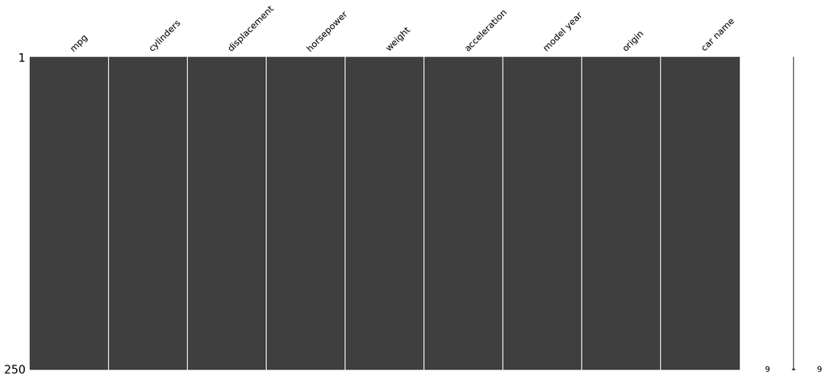

```python
msno.matrix(ds.sample(250))
```

```python
ds.isnull().sum()
```

|  | 0 |
| --- | --- |
| mpg | 0 |
| cylinders | 0 |
| displacement | 0 |
| horsepower | 0 |
| weight | 0 |
| acceleration | 0 |
| model year | 0 |
| origin | 0 |
| car name | 0 |

**dtype:** int64

# Heatmap

How strongly does the presense or absence of one variable affect the presense of another.

There are no missing values (all zeros), therefore no missingness to correlate.

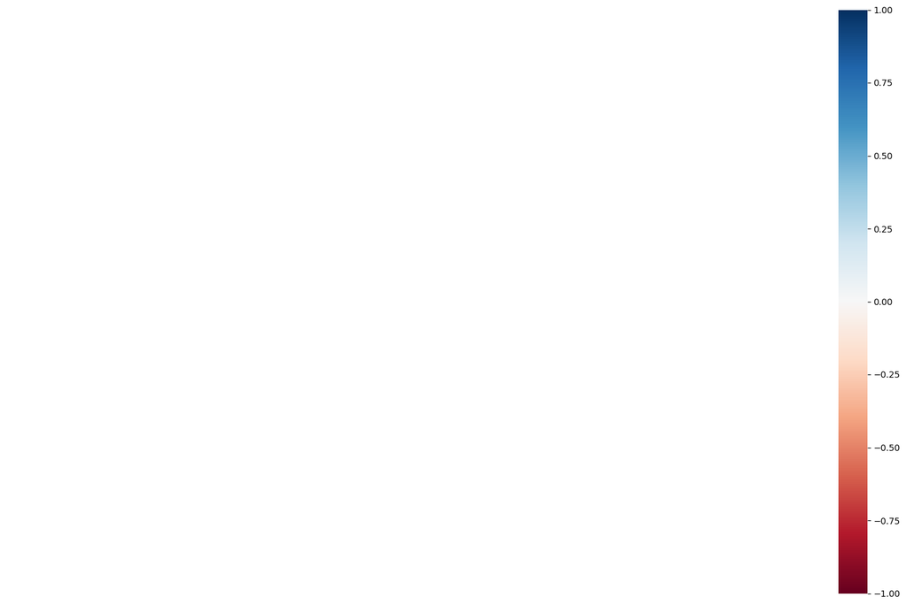

```python
msno.heatmap(ds)
```

# Dendrogram

A dendrogram visualizes the hierarchical clustering of variables based on their nullity correlation (how often they are missing together).

The lines in the dendrogram represent the distance between clusters of variables based on their missingness. The closer the lines are joined at the bottom, the more correlated the missingness is between those variables.

Similar to the heatmap, since this dataset has no missing values, there is no missingness to cluster.

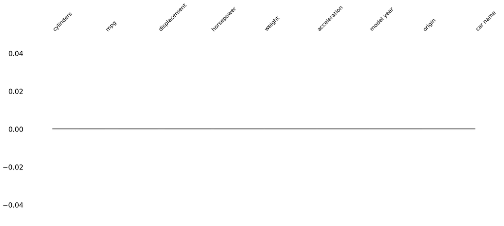

```python
msno.dendrogram(ds)
```

# Estimate Skewness and Kurtosis

Skewness measures the asymmetry of the distribution of data around its mean.

Kurtosis measures the "tailedness" of the distribution, indicating how heavily the tails differ from the tails of a normal distribution.

```python
ds['horsepower'] = ds['horsepower'].replace('?', np.nan).astype(float)
numeric_ds = ds.select_dtypes(include=[np.number])
print(numeric_ds.skew())
print(numeric_ds.kurt())
```

```
mpg             0.457066
cylinders       0.526922
displacement    0.719645
horsepower      1.087326
weight          0.531063
acceleration    0.278777
model year      0.011535
origin          0.923776
dtype: float64
mpg            -0.510781
cylinders      -1.376662
displacement   -0.746597
horsepower      0.696947
weight         -0.785529
acceleration    0.419497
model year     -1.181232
origin         -0.817597
dtype: float64
```

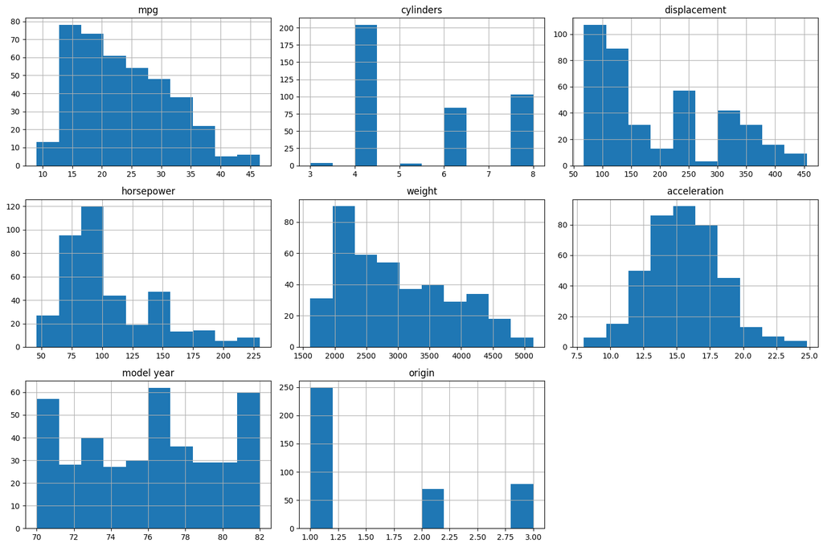

```python
# this code provides a quick way to visualize the distribution of values within
# each of the numeric features, helping to see their shapes, central tendencies, and spread
import matplotlib.pyplot as plt

numeric_ds.hist(figsize=(15, 10))
plt.tight_layout()
plt.show()
```

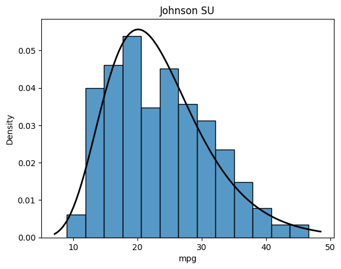

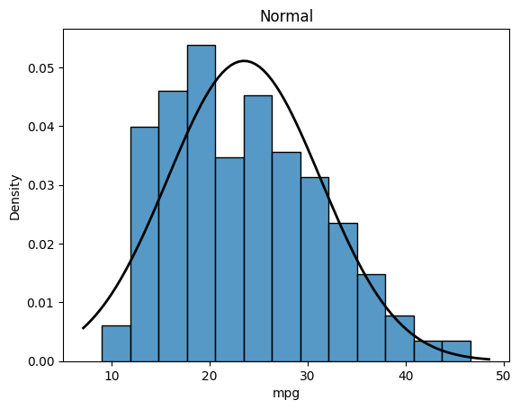

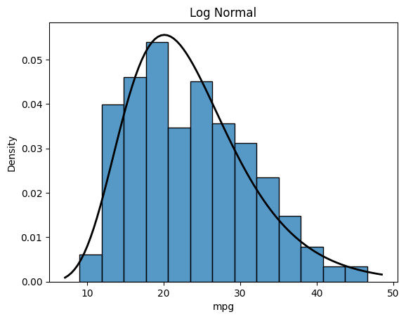

```python
import numpy as np
import matplotlib.pyplot as plt
import seaborn as sns
import scipy.stats as st

y = ds['mpg']

# Plot with Johnson SU distribution
plt.figure(1)
plt.title('Johnson SU')
sns.histplot(y, kde=False, stat='density') # Use histplot and stat='density'
xmin, xmax = plt.xlim()
x = np.linspace(xmin, xmax, 100)
p = st.johnsonsu.pdf(x, *st.johnsonsu.fit(y))
plt.plot(x, p, 'k', linewidth=2)


# Plot with Normal distribution
plt.figure(2)
plt.title('Normal')
sns.histplot(y, kde=False, stat='density') # Use histplot and stat='density'
xmin, xmax = plt.xlim()
x = np.linspace(xmin, xmax, 100)
p = st.norm.pdf(x, *st.norm.fit(y))
plt.plot(x, p, 'k', linewidth=2)


# Plot with Log Normal distribution
plt.figure(3)
plt.title('Log Normal')
sns.histplot(y, kde=False, stat='density') # Use histplot and stat='density'
xmin, xmax = plt.xlim()
x = np.linspace(xmin, xmax, 100)
p = st.lognorm.pdf(x, *st.lognorm.fit(y))
plt.plot(x, p, 'k', linewidth=2)

plt.show()
```

The Johnson SU distribution is a very flexible four-parameter distribution that can fit a wide variety of data shapes, including skewed and heavy-tailed distributions. The Log Normal distribution is a two-parameter distribution that is also used for positively skewed data.

It's possible that for the specific characteristics of the 'mpg' data, both the Log Normal and Johnson SU distributions provide a reasonably good and visually similar fit. While they are different theoretical distributions, their shapes can overlap depending on the parameters fitted to the data.

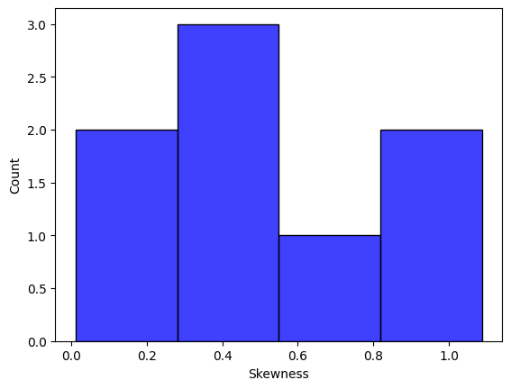

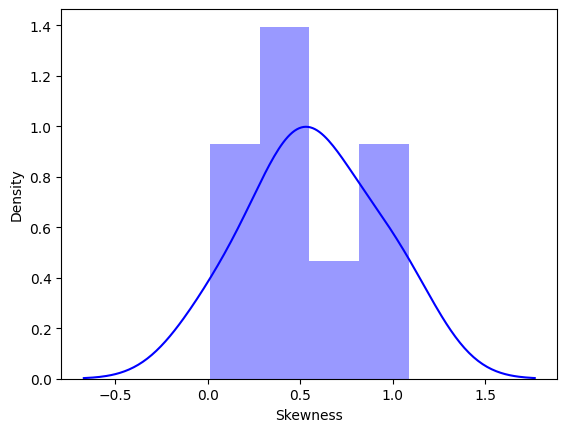

```python
sns.histplot(numeric_ds.skew(), color='blue')
plt.xlabel('Skewness')
plt.show()

sns.distplot(numeric_ds.skew(),color='blue',axlabel ='Skewness')
```

We see that the skewness values are spread across a range of positive values, with a few features having skewness between 0 and 0.5, some between 0.5 and 1, and one above 1. This visually confirms that several of the numeric features exhibit positive skewness, and the degree of skewness varies among them.

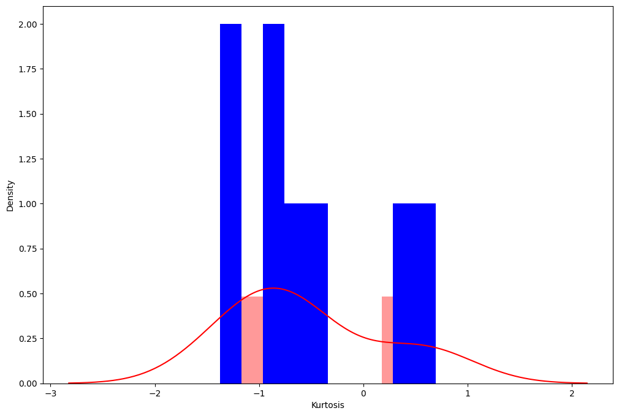

```python
plt.figure(figsize = (12,8))
sns.distplot(numeric_ds.kurt(),color='r',axlabel ='Kurtosis',norm_hist= False, kde = True,rug = False)
plt.hist(numeric_ds.kurt(),orientation = 'vertical',histtype = 'bar',label ='Kurtosis', color ='blue')
plt.show()
```

The numeric features generally deviate from a symmetrical, normal distribution, often exhibiting positive skewness and varying degrees of peakedness/tailedness.